# Corro_ML2_IndivProject

[figure not shown]

Stock price prediction using

Reinforcement Learning

by EUGENIO CEDRIC T. CORRO

```python
import math
import numpy as np
import random
import pandas as pd
import matplotlib.pyplot as plt
from collections import deque

import keras
from keras.models import Sequential
from keras.models import load_model
from keras.layers import Dense
from keras.optimizers import Adam

from IPython.core.display import HTML
import pprint
```

```python
font = "Roboto-Regular.ttf"
pp = pprint.PrettyPrinter(indent=4, width=100)


HTML('''
<style>
.output_png {
    display: table-cell;
    text-align: center;
    vertical-align: middle;
}

</style>


<script>
code_show=true;
function code_toggle() {
 if (code_show){
 $('div.input').hide();
 } else {
 $('div.input').show();
 }
 code_show = !code_show
}
$( document ).ready(code_toggle);
</script>
<form action="javascript:code_toggle()"><input type="submit" value="Click here to toggle on/off the raw code."></form>
''')
```

EXECUTIVE SUMMARY

Stock price prediction using various techniques is a classic problem that many researchers have been tackling for many years. Although efficient market hypothesis states that it is not possible to predict stock prices given its random nature, many still attempt to find patterns in price movements. Technical analysts take advantage of factors based on prices and volume to figure out potential opportunities to make money in the short- or long-run. In the Philippines, the Philippines Stock Exchange, Inc. (PSE) is the national stock exchange. In 2019, the PSE had a market capitalization of PhP 13.395 trillion with an average value turnover of PhP 7.29 billion.

**Keywords**: *Stock price prediction, reinforcement learning, Philippine stocks*

INTRODUCTION: A BRIEF OVERVIEW ON REINFORCEMENT LEARNING

[figure not shown]

*Figure 1. Preception-action learning loop*

**Reinforcement learning (RL)** is a computational approach of automating learning and decision-making. It is based upon a formal framework in which an *agent* interacts with an *enviroment* in the form of *actions*, *rewards* and *states*. The idea of *reinforcement learning* is grounded on the idea that we learn as we interact with the environment [1] as can be seen in *Figure 1*.

Aside from the *agent* and the *environment*, there are sub-elements that play a role in process of reinforcement learning - the *policy*, the *reward function*, the *value function.* and the *model* [1]. These sub-elements can be briefly described as follows:

1. **Policy** is a mapping from the percieved states of the environment to the corresponding action to be taken by the *agent*. It describes the way an agent reacts on the environment he observes.
2. **Reward function** is a mapping from the perceived states of the environment to a numerical value known as the *reward* which indicates the non-desirability or desirability of those states.
3. **Value function** is a mapping from perceived state of the environment to a numerical value which is the total reward an agent can expect in the long run starting from the said state.
4. The **model**, loosely speaking, is the one that mimics the behavior of the environment. It can be responsible in the predicting of the next state and reward given the current state and action.

These mentioned elements and sub-elements of RL have their counterparts in this study which focuses on the use of RL in stock trading. It is discussed in the methodology section where the necessary functions are being defined.

BUSINESS VALUE

**Stock traders and investors:** They can consider a reinforcement-based model in predicting stock price as part of their decision when trading stocks.

**Researchers:** They can consider a rewards-based model when dealing with a stock price prediction research.

DATA DESCRIPTION

The **daily closing prices** of the PSEi from January 2015 to December 2020 are used in this study. The data were collected from [Philippine Stock Exchange Composite Index RESTful API](http://phisix-api2.appspot.com/) using the code provided below.

```python
# def get_stocks(stock_code, start_date, end_date):
#     """
#     Get stock info from start_date to end_date.

#     PARAMETERS
#     ----------
#     stock_code : list
#         List of stock codes to retrieve info of.
#     start_date : str
#         Start date of data with format 'YYYY-MM-DD'.
#     end_date : str
#         End date of data with format 'YYYY-MM-DD'.

#     RETURN
#     ------
#     stocks : pandas.DataFrame
#         DataFrame with stock info name-price-symbol-date.
#     """

#     dates = (pd.date_range(start=start_date,
#                            end=end_date).to_series()
#                                         .apply(lambda x :
#                                                x.strftime("%Y-%m-%d")))

#     stocks = pd.DataFrame()
#     for code in stock_code:
#         for date in dates:
#             data = ''
#             wp_endpoint = ('http://phisix-api2.appspot.com/stocks/' + code
#                            + '.' + date +'.json')
#             data = requests.get(wp_endpoint).text
#             if data:
#                 stock = json.loads(data)
#                 stock_data = (pd.DataFrame(stock['stock'][0])
#                                           .reset_index(drop=True)
#                                           .drop(1)
#                                           .drop('percent_change', axis=1))
#                 stock_data['date'] = date
#                 stocks = stocks.append(stock_data)
#                 # time.sleep(0.5)
#     return stocks
```

```python
# stock_code = ['PSEI']
# start_date = '2015-01-01'
# end_date = '2020-12-31'

# stocks = get_stocks(stock_code, start_date, end_date)
# stocks.to_csv('psei_2015_2020.csv', index=False)
```

METHODOLOGY

To clearly understand the flow of how this study is done, let us first define how we translate the important elements and sub-elements of RL in the lens of stock trading. The elements and sub-elements of RL in this study are described as follows:

1. The perceived states are in the form of daily gain or loss of a certain stock which are individually mapped to the interval (0,1) through the sigmoid function. The number of daily gain/loss to be included is based on the parameter `window_size`.
2. The policy is a five-layer neural network including the input and output layers. The output layer has two nodes which represent the actions of *buy/hold* or *sell*. Since this study is intended to understand in-depth how reinforcement learning is applied in stock trading, the following rule is strictly followed: a. If the agent is not holding any stock, the decision is automatically to buy a stock. b. If the agent is already holding a stock and the policy NN decides to buy a stock, the agent simply "hold"s the stock he has. c. If the agent is already holding a stock and the policy NN decides to sell a stock, then the agent shall sell the stock.
3. The reward is set to be the $max\{0, \text{gain after selling}\}$. This means that if a loss is realized upon selling, the reward is set to 0. Otherwise, the reward is the gain realized.
4. The value function can be associated with the way the policy is trained using the past `batch_size` instances when there was a *reward* being recorded, that is, every time a stock is sold.

### 1. Defining a Class for the `Agent`

The method `_model` defines the policy that decides whether to *buy/hold* or to *sell*. The method `act`maps the perceived states to the decision of *buy/hold* or *sell* using the policy. Lastly, the method `experience_replay` trains the policy based on a sequence of state-reward pairs.

```python
class Agent:
    def __init__(self, state_size, is_eval=False, model_name=""):
        self.state_size = state_size # normalized previous days
        self.action_size = 2 # buy/hold or sell
        self.memory = deque(maxlen=1000)
        self.inventory = []
        self.model_name = model_name
        self.is_eval = is_eval
        self.gamma = 0.95
        self.epsilon = 1.0
        self.epsilon_min = 0.01
        self.epsilon_decay = 0.995
        if is_eval:
            self.model = load_model(model_name)
        else:
            self.model = self._model()

    def _model(self):
        model = Sequential()
        model.add(Dense(units=64, input_dim=self.state_size,
                        activation="relu"))
        model.add(Dense(units=32, activation="relu"))
        model.add(Dense(units=8, activation="relu"))
        model.add(Dense(self.action_size, activation="linear"))
        model.compile(loss="mse", optimizer=Adam(lr=0.001))
        return model

    def act(self, state):
        if not self.is_eval and random.random() <= self.epsilon:
            return random.randrange(self.action_size)
        options = self.model.predict(state)
        return np.argmax(options[0])

    def experience_replay(self, batch_size):
        mini_batch = list(self.memory)[-batch_size:]

        for state, action, reward, next_state, done in mini_batch:
            target = reward
            if not done:
                target = (reward + self.gamma *
                          np.amax(self.model.predict(next_state)[0]))
            target_f = self.model.predict(state)
            target_f[0][action] = target
            self.model.fit(state, target_f, epochs=1, verbose=0)

        if self.epsilon > self.epsilon_min:
            self.epsilon *= self.epsilon_decay
```

### 2. Define functions necessary for the processes

```python
def format_print(n):
    return("-PhP " if n < 0 else "PhP ")+"{0:.2f}".format(abs(n))


def get_data(filename):
    df = pd.read_csv(filename + '.csv', usecols=['Close'])
    return list(df.Close.values)


def sigmoid(x):
    try:
        ans = 1 / (1+math.exp(-x))
    except OverflowError:
        ans = 0
    return ans


def get_state(df, today, window_size):
    data = df.copy()
    d = today - window_size + 1

    # Pad with t0 data
    if d >= 0:
        block = data[d:today + 1]
    else:
        block = -d * [data[0]] + data[0 : today + 1]
    res = []
    for i in range(window_size - 1):
        res.append(sigmoid(block[i + 1] - block[i]))
    return np.array([res])
```

### 3. Define main function for the reinforcement learning algorithm

Th function `run_rl_stocks` perform displays the action of the agent and the performance each selling decision. Note that `window_size` determines the number of days prior to the current day in which the perceived states is being based upon in deciding on the action. On the other hand, `batch_size` determines the number of *sell* days prior to the current *sell* day in which the policy will be trained on using the collected state-reward sequence.

```python
def run_rl_stocks(stock_name, window_size, batch_size, epoch_count):
    """Run RL model."""
    # stock_name = input("Enter stock_name: ")
    # window_size = int(input("Window_size: "))
    # epoch_count = int(input("Number of epochs: "))
    # batch_size = int(input("Batch size: "))
    # print("\n")

    agent = Agent(window_size)
    data = get_data(stock_name)
    l = len(data) - 1
    markers = []
    profit_trend = []

    for e in range(1, epoch_count + 1):
        print("Epoch " + str(e) + "/" + str(epoch_count))
        state = get_state(data, 0, window_size + 1)
        total_profit = 0
        agent.inventory = []
        done = False

        for t in range(l):
            action = agent.act(state)

            next_state = get_state(data, t, window_size + 1)
            reward = 0

            if len(agent.inventory) == 0:
                # Buy stock
                agent.inventory.append(data[t])
                print("Day {} \tBuy: ".format(t) + format_print(data[t]))
                markers.append((t, data[t], total_profit, 'buy'))

            elif action == 0 and len(agent.inventory) > 0:
                # Hold bought stock
                print("Day {} \tHold...: ".format(t))
                markers.append((t, data[t], total_profit, 'hold'))

            elif action == 1 and len(agent.inventory) > 0:
                # Sell stock bought.
                bought_price = agent.inventory.pop(0)
                agent.inventory = []
                reward = max(data[t] - bought_price, 0)
                total_profit += data[t] - bought_price
                print("Day {} \tSell: ".format(t) + format_print(data[t])
                      + " | Profit: " + format_print(data[t] - bought_price)
                      + " \t| Cumulative Profit: "+format_print(total_profit))
                markers.append((t, data[t], total_profit, 'sell'))

            if t == (l - 1):
                done = True

            agent.memory.append((state, action, reward, next_state, done))
            state = next_state

            if done:
                print("===============================================")
                print("Total Profit: " + format_print(total_profit))
                print("===============================================")

            if len(agent.memory) > batch_size:
                agent.experience_replay(batch_size)

#     mod_name = input("Enter model name: ")
    mod_name = "window" + str(window_size)
    agent.model.save(mod_name)

    return pd.DataFrame(markers, columns=['day', 'price',
                                          'cumulative_profit' , 'action'])
```

### 4. Implement RL-based model in stock trading.

In this step, three values of `window_size` were considered in the model - $10, 30$ and $50$. Furthermore, due to the amount of run-time, a fixed value of `batch_size`$=45$ and `epoch_count`$=1$ were considered.

### 5. Comparing results of RL-based model with varying window sizes and classic *Buy-and-Hold* strategy

Straightforward metrics, which are the total gain or loss realized, and the corresponding percentage with respect to the initial value of investment, are used to compare the performance of each model.

RESULTS AND DISCUSSION

```python
stock_name = 'psei_train'
epoch_count = 1
batch_size = 45
```

#### Case 1: Window size of 10 trading days

```python
window_size = 10

markers10 = run_rl_stocks(stock_name, window_size, batch_size, epoch_count)
```

```
Day 0 	Buy: PhP 6911.86
Day 1 	Hold...:
Day 2 	Hold...:
Day 3 	Sell: PhP 6820.60 | Profit: -PhP 91.26 	| Cumulative Profit: -PhP 91.26
Day 4 	Buy: PhP 6735.01
Day 5 	Hold...:
Day 6 	Hold...:
Day 7 	Hold...:
Day 8 	Sell: PhP 6905.70 | Profit: PhP 170.69 	| Cumulative Profit: PhP 79.43
Day 9 	Buy: PhP 6867.07
Day 10 	Hold...:
Day 11 	Sell: PhP 6966.18 | Profit: PhP 99.11 	| Cumulative Profit: PhP 178.54
Day 12 	Buy: PhP 7002.42
Day 13 	Sell: PhP 6983.61 | Profit: -PhP 18.81 	| Cumulative Profit: PhP 159.73
Day 14 	Buy: PhP 6952.08
Day 15 	Hold...:
Day 16 	Hold...:
Day 17 	Hold...:
Day 18 	Sell: PhP 6618.88 | Profit: -PhP 333.20 	| Cumulative Profit: -PhP 173.47
Day 19 	Buy: PhP 6575.43
Day 20 	Sell: PhP 6288.26 | Profit: -PhP 287.17 	| Cumulative Profit: -PhP 460.64
Day 21 	Buy: PhP 6330.55
Day 22 	Hold...:
Day 23 	Hold...:
Day 24 	Sell: PhP 6449.50 | Profit: PhP 118.95 	| Cumulative Profit: -PhP 341.69
Day 25 	Buy: PhP 6335.09
Day 26 	Sell: PhP 6357.05 | Profit: PhP 21.96 	| Cumulative Profit: -PhP 319.73
Day 27 	Buy: PhP 6259.61
Day 28 	Sell: PhP 6084.28 | Profit: -PhP 175.33 	| Cumulative Profit: -PhP 495.06
Day 29 	Buy: PhP 6208.05
Day 30 	Hold...:
Day 31 	Hold...:
Day 32 	Sell: PhP 6507.22 | Profit: PhP 299.17 	| Cumulative Profit: -PhP 195.89
Day 33 	Buy: PhP 6563.38
Day 34 	Sell: PhP 6687.62 | Profit: PhP 124.24 	| Cumulative Profit: -PhP 71.65
Day 35 	Buy: PhP 6701.36
Day 36 	Hold...:
Day 37 	Hold...:
Day 38 	Hold...:
Day 39 	Hold...:
```

[output cut: 941 more lines]

```
Day 981 	Buy: PhP 7736.18
Day 982 	Sell: PhP 7786.41 | Profit: PhP 50.23 	| Cumulative Profit: PhP 2795.54
Day 983 	Buy: PhP 7741.07
Day 984 	Sell: PhP 7877.63 | Profit: PhP 136.56 	| Cumulative Profit: PhP 2932.10
Day 985 	Buy: PhP 7701.60
Day 986 	Sell: PhP 7730.45 | Profit: PhP 28.85 	| Cumulative Profit: PhP 2960.96
Day 987 	Buy: PhP 7733.67
Day 988 	Sell: PhP 7653.94 | Profit: -PhP 79.73 	| Cumulative Profit: PhP 2881.23
Day 989 	Buy: PhP 7773.12
Day 990 	Sell: PhP 7872.60 | Profit: PhP 99.48 	| Cumulative Profit: PhP 2980.71
Day 991 	Buy: PhP 7842.28
===============================================
Total Profit: PhP 2980.71
===============================================
INFO:tensorflow:Assets written to: window10/assets
```

#### Case 2: Window size of 30 trading days

```python
window_size = 30

markers30 = run_rl_stocks(stock_name, window_size, batch_size, epoch_count)
```

```
Day 0 	Buy: PhP 6911.86
Day 1 	Hold...:
Day 2 	Sell: PhP 6848.25 | Profit: -PhP 63.61 	| Cumulative Profit: -PhP 63.61
Day 3 	Buy: PhP 6820.60
Day 4 	Sell: PhP 6735.01 | Profit: -PhP 85.59 	| Cumulative Profit: -PhP 149.20
Day 5 	Buy: PhP 6745.99
Day 6 	Hold...:
Day 7 	Sell: PhP 6807.72 | Profit: PhP 61.73 	| Cumulative Profit: -PhP 87.47
Day 8 	Buy: PhP 6905.70
Day 9 	Hold...:
Day 10 	Sell: PhP 6910.34 | Profit: PhP 4.64 	| Cumulative Profit: -PhP 82.83
Day 11 	Buy: PhP 6966.18
Day 12 	Sell: PhP 7002.42 | Profit: PhP 36.24 	| Cumulative Profit: -PhP 46.59
Day 13 	Buy: PhP 6983.61
Day 14 	Hold...:
Day 15 	Hold...:
Day 16 	Hold...:
Day 17 	Sell: PhP 6813.90 | Profit: -PhP 169.71 	| Cumulative Profit: -PhP 216.30
Day 18 	Buy: PhP 6618.88
Day 19 	Sell: PhP 6575.43 | Profit: -PhP 43.45 	| Cumulative Profit: -PhP 259.75
Day 20 	Buy: PhP 6288.26
Day 21 	Sell: PhP 6330.55 | Profit: PhP 42.29 	| Cumulative Profit: -PhP 217.46
Day 22 	Buy: PhP 6494.13
Day 23 	Sell: PhP 6408.76 | Profit: -PhP 85.37 	| Cumulative Profit: -PhP 302.83
Day 24 	Buy: PhP 6449.50
Day 25 	Sell: PhP 6335.09 | Profit: -PhP 114.41 	| Cumulative Profit: -PhP 417.24
Day 26 	Buy: PhP 6357.05
Day 27 	Hold...:
Day 28 	Hold...:
Day 29 	Hold...:
Day 30 	Hold...:
Day 31 	Hold...:
Day 32 	Sell: PhP 6507.22 | Profit: PhP 150.17 	| Cumulative Profit: -PhP 267.07
Day 33 	Buy: PhP 6563.38
Day 34 	Hold...:
Day 35 	Sell: PhP 6701.36 | Profit: PhP 137.98 	| Cumulative Profit: -PhP 129.09
Day 36 	Buy: PhP 6642.45
Day 37 	Sell: PhP 6521.48 | Profit: -PhP 120.97 	| Cumulative Profit: -PhP 250.06
Day 38 	Buy: PhP 6652.83
Day 39 	Hold...:
```

[output cut: 941 more lines]

```
Day 981 	Buy: PhP 7736.18
Day 982 	Sell: PhP 7786.41 | Profit: PhP 50.23 	| Cumulative Profit: PhP 1878.36
Day 983 	Buy: PhP 7741.07
Day 984 	Sell: PhP 7877.63 | Profit: PhP 136.56 	| Cumulative Profit: PhP 2014.92
Day 985 	Buy: PhP 7701.60
Day 986 	Sell: PhP 7730.45 | Profit: PhP 28.85 	| Cumulative Profit: PhP 2043.77
Day 987 	Buy: PhP 7733.67
Day 988 	Sell: PhP 7653.94 | Profit: -PhP 79.73 	| Cumulative Profit: PhP 1964.04
Day 989 	Buy: PhP 7773.12
Day 990 	Sell: PhP 7872.60 | Profit: PhP 99.48 	| Cumulative Profit: PhP 2063.52
Day 991 	Buy: PhP 7842.28
===============================================
Total Profit: PhP 2063.52
===============================================
INFO:tensorflow:Assets written to: window30/assets
```

#### Case 3: Window size of 50 trading days

```python
window_size = 50

markers50 = run_rl_stocks(stock_name, window_size, batch_size, epoch_count)
```

```
Day 0 	Buy: PhP 6911.86
Day 1 	Hold...:
Day 2 	Hold...:
Day 3 	Sell: PhP 6820.60 | Profit: -PhP 91.26 	| Cumulative Profit: -PhP 91.26
Day 4 	Buy: PhP 6735.01
Day 5 	Hold...:
Day 6 	Sell: PhP 6701.35 | Profit: -PhP 33.66 	| Cumulative Profit: -PhP 124.92
Day 7 	Buy: PhP 6807.72
Day 8 	Sell: PhP 6905.70 | Profit: PhP 97.98 	| Cumulative Profit: -PhP 26.94
Day 9 	Buy: PhP 6867.07
Day 10 	Hold...:
Day 11 	Sell: PhP 6966.18 | Profit: PhP 99.11 	| Cumulative Profit: PhP 72.17
Day 12 	Buy: PhP 7002.42
Day 13 	Sell: PhP 6983.61 | Profit: -PhP 18.81 	| Cumulative Profit: PhP 53.36
Day 14 	Buy: PhP 6952.08
Day 15 	Sell: PhP 6833.42 | Profit: -PhP 118.66 	| Cumulative Profit: -PhP 65.30
Day 16 	Buy: PhP 6835.13
Day 17 	Hold...:
Day 18 	Sell: PhP 6618.88 | Profit: -PhP 216.25 	| Cumulative Profit: -PhP 281.55
Day 19 	Buy: PhP 6575.43
Day 20 	Hold...:
Day 21 	Sell: PhP 6330.55 | Profit: -PhP 244.88 	| Cumulative Profit: -PhP 526.43
Day 22 	Buy: PhP 6494.13
Day 23 	Hold...:
Day 24 	Sell: PhP 6449.50 | Profit: -PhP 44.63 	| Cumulative Profit: -PhP 571.06
Day 25 	Buy: PhP 6335.09
Day 26 	Hold...:
Day 27 	Sell: PhP 6259.61 | Profit: -PhP 75.48 	| Cumulative Profit: -PhP 646.54
Day 28 	Buy: PhP 6084.28
Day 29 	Hold...:
Day 30 	Hold...:
Day 31 	Hold...:
Day 32 	Hold...:
Day 33 	Sell: PhP 6563.38 | Profit: PhP 479.10 	| Cumulative Profit: -PhP 167.44
Day 34 	Buy: PhP 6687.62
Day 35 	Sell: PhP 6701.36 | Profit: PhP 13.74 	| Cumulative Profit: -PhP 153.70
Day 36 	Buy: PhP 6642.45
Day 37 	Hold...:
Day 38 	Sell: PhP 6652.83 | Profit: PhP 10.38 	| Cumulative Profit: -PhP 143.32
Day 39 	Buy: PhP 6765.13
```

[output cut: 941 more lines]

```
Day 981 	Sell: PhP 7736.18 | Profit: -PhP 43.62 	| Cumulative Profit: PhP 341.76
Day 982 	Buy: PhP 7786.41
Day 983 	Sell: PhP 7741.07 | Profit: -PhP 45.34 	| Cumulative Profit: PhP 296.42
Day 984 	Buy: PhP 7877.63
Day 985 	Sell: PhP 7701.60 | Profit: -PhP 176.03 	| Cumulative Profit: PhP 120.39
Day 986 	Buy: PhP 7730.45
Day 987 	Sell: PhP 7733.67 | Profit: PhP 3.22 	| Cumulative Profit: PhP 123.60
Day 988 	Buy: PhP 7653.94
Day 989 	Sell: PhP 7773.12 | Profit: PhP 119.18 	| Cumulative Profit: PhP 242.79
Day 990 	Buy: PhP 7872.60
Day 991 	Sell: PhP 7842.28 | Profit: -PhP 30.32 	| Cumulative Profit: PhP 212.46
===============================================
Total Profit: PhP 212.46
===============================================
INFO:tensorflow:Assets written to: window50/assets
```

#### Baseline case: Buy-and-Hold strategy

```python
prices = get_data("psei_train")

print("Buy-and-Hold Strategy")
print("======================")
print("Gain (in PhP) =", prices[-1] - prices[0])
```

```
Buy-and-Hold Strategy
======================
Gain (in PhP) = 903.3999029999995
```

### Model Comparison

#### 1. Gain (Loss) Comparison

| Model | Window Size | Gain (Loss) in PhP | Precentage Gain (Loss) |
| --- | --- | --- | --- |
| Reinforcement Learning | $10$ | $2980.71$ | $43.12 \%$ |
| Reinforcement Learning | $30$ | $2063.52$ | $29.85 \%$ |
| Reinforcement Learning | $50$ | $212.46$ | $3.07 \%$ |
| Buy-and-Hold | NA | $903.40$ | $13.07 \%$ |

*Table 1. Gain (Loss) comparison of different models*

#### 2. Cumulative Profit Trend Comparison

*Note: For the Buy-and-Hold strategy, the cumulative profit for day $t$ is the profit earned if the stock is sold at day $t$.*

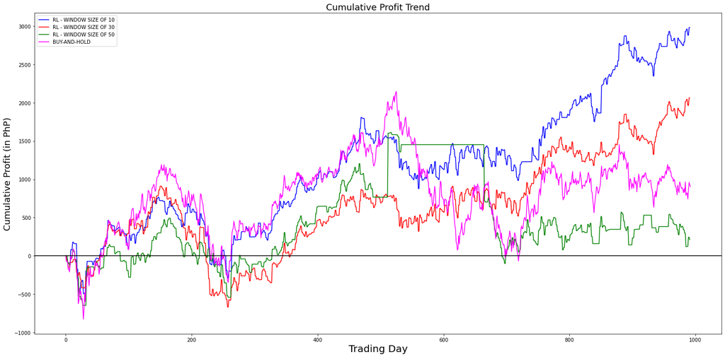

```python
# Calculate daily profit under Buy-and-Hold strategy
data = pd.read_csv('psei_train.csv', usecols=['Close'])
initial = data.Close.values[0]
data['daily_profit'] = data.Close.apply(lambda x : x - initial)

# Plot trend of profit for each model
plt.figure(figsize=(25,12))
plt.plot(range(len(markers10)),
         markers10.cumulative_profit.values,
         c='b', label="RL - WINDOW SIZE OF 10")
plt.plot(range(len(markers30)),
         markers30.cumulative_profit.values,
         c='r', label="RL - WINDOW SIZE OF 30")
plt.plot(range(len(markers50)),
         markers50.cumulative_profit.values,
         c='g', label="RL - WINDOW SIZE OF 50")
plt.plot(range(len(data)),
         data.daily_profit.values,
         c='magenta', label="BUY-AND-HOLD")
plt.legend()
plt.axhline(0, c='black')
plt.xlabel("Trading Day", fontsize=20)
plt.ylabel("Cumulative Profit (in PhP)", fontsize=18)
plt.title("Cumulative Profit Trend", fontsize=18)
plt.show();
```

*Figure 2. Comparison of cumulative profit achieved by different models*

CONCLUSION AND RECOMMENDATION

### Summary

1. The best-performing reinforcement learning model in this study outperformed the classical *Buy-and-Hold* strategy by more than three times of the gain the latter earned.
2. It is observed that an RL-based model with a smaller `window_size` at a fixed `batch_size`$=45$ performs better. It can be associated by a phenomenon in stock trading in which price actions can sometimes be affected only by price actions in the near past. This claim still needs further studies to be verified.
3. RL-based models may not perform well in the short given that there is no policy being trained yet. However, as the underlying network of the policy learns more through a sequence of *state-reward* pair collected in the past, the model can significantly improve its performance.

### Recommendation:

1. Given that the policy is responsible for the decision to buy/hold or sell, it would be interesting to try out other neural network architectures for the policy.
2. Based on the observation, given a fixed batch size, the gain increases as the window size decreases . It would be interesting to know theoretically or empirically if there exists a pattern of batch size-window size pair to which the RL-based model performance follows.
3. In the underlying neural network of the policy, the output layer only has two nodes (Buy/Hold or Sell). More actions can be considered by increasing the number of nodes in the output layer of the said neural network. Actions such as "*not buying immediately after selling*" can be considered.

REFERENCES

[1] Sutton, R. S., & Barto, A. G. (2018). Reinforcement learning: An introduction. *MIT press*.

[2] Arulkumaran, K., Deisenroth, M. P., Brundage, M., & Bharath, A. A. (2017). A brief survey of deep reinforcement learning. arXiv preprint arXiv:1708.05866.

[3] Gonzales, I. (2020). Market on short-lived high, but investors optimistic for 2020. Philstar Global. Retrieved from: https://www.philstar.com/business/2020/01/01/1981088/market-short-lived-high-investors-optimistic-2020

[4] Predicting Stock Prices using Reinforcement Learning. Retrieved from: https://www.analyticsvidhya.com/blog/2020/10/reinforcement-learning-stock-price-prediction/#:~:text=The%20concept%20of%20reinforcement%20learning,based%20on%20the%20current%20environment.

```python
! jupyter nbconvert --to html Corro_ML2_IndivProject.ipynb
```

[output not shown]